# Código para hallar la densidad de tau

Gerardo Martínez

15 de noviembre de 2018

El siguiente código mostrará cómo hallar la densidad de $\tau$ con

$$\begin{equation}
\tau = \inf_{t \geq 0} \{X_t \in \{0,1\}\}
\end{equation}$$

y $X = \{X_t\}_{t \geq 0}$ la solución de la ecuación diferencial estocástica

$$\begin{equation*}
\left\{
\begin{array}{rcl}
dX_t & = & (-u_1X_t + u_2 (1-X_t) + \\
& & X_t^2 (1-X_t) \sigma_{11} + X_t (1-X_t)(1-2X_t) \sigma_{12} - X_t(1-X_t)^2 \sigma_{22}) dt \\
& & + \sqrt{X_t(1-X_t)} \, dW_t \\
X_0 & = & p_0 \in (0,1)
\end{array}
\right.
\end{equation*}$$
donde
$$\begin{equation}
\omega_{ij} = 1 + \frac{\sigma_{ij}}{2N}, \qquad \mu_i = \frac{u_i}{2N}
\end{equation}$$

Para obtener simulaciones de $\tau$ simularemos trayectorias de $X$ con el esquema de Milstein hasta que alcance uno de los estados $0$ o $1$.

Para esto consideraremos la función $\texttt{densidadTau()}$ que es una modificación de la función $\texttt{trayectoriasWFMS()}$. En este caso, simularemos trayectorias hasta un tiempo $T$ muy grande y detendremos la simulación si $X_t \in \{0,1\}$ con $t \leq T$: el algoritmo devolverá los tiempos $t$ en donde la trayectoria simulada alcanza los estados $0$ o $1$. En caso de que $X_t \notin \{0,1\}$ para ningún $t \leq T$, entonces el algoritmo devolverá el valor $T$. Se recomienda utilizar un tiempo $T$ suficientemente grande para evitar la menor cantidad posible de valores truncados.

$\texttt{densidadTau()}$ tendrá los siguientes parámetros:

- $k$: Cantidad de observaciones de $\tau$.
- $n$: Precisión de la solución de la ecuación diferencial estocástica según el esquema de Milstein.
- $T$: Tiempo $T$ hasta donde se realiza la simulación.
- $N$: Tamaño poblacional.
- $p_0$: Valor inicial de $X$.
- $u_1$: Probabilidad reescalada según $N$ de mutar del alelo $A$ al $a$.
- $u_2$: Probabilidad reescalada según $N$ de mutar del alelo $a$ al $A$.
- $s_{11}$: Viabilidad reescalada según $N$ del genotipo $AA$.
- $s_{12}$: Viabilidad reescalada según $N$ del genotipo $Aa$.
- $s_{22}$: Viabilidad reescalada según $N$ del genotipo $aa$.

```r
densidadTau <- function(k, n, T, p0, N, u1, u2, s11, s12, s22){
    # se construye un vector tau
    # que será completado con los valores simulados de tau
    tau <- rep(0, k)

    if (u1 == 0) {
        if (u2 == 0) {
            for (j in 1:k) {
                # inicializamos la tr en p0
                tr  <- p0

                # construimos una variable auxiliar
                # la utilizaremos para detener el algoritmo
                aux <- 0

                # inicializamos el iterador
                i <- 1

                # Bucle
                while ((aux == 0)&(i <= n-1)) {
                    if (tr != 0) {
                        if (tr != 1) {

                            # si la frecuencia del alelo
                            # es distinta de 0 o 1,
                            # utilizo el proceso de difusión

                            W <- sqrt(T / n) * rnorm(1)
                            tr <- tr +
                            (tr) ^ 2 * (1 - tr) * s11 * 2 * N * T / n +
                            (tr) * (1 - tr) * (1 - 2 * tr) * 2 * N * s12 * T / n -
                            (tr) * (1 - tr) ^ 2 * 2 * N * s22 * T / n +
                            sqrt(tr * (1 - tr)) * W +
                            (((-2 * tr + 1) / (4)) * (W ^ 2 - T / n))

                            # en caso de que por error de simulación
                            # se obtenga un valor menor que 0
                            if (tr <= 0) {
                            tr <- 0
                            }

                            # en caso de que por error de simulación
                            # se obtenga un valor mayor que 1
                            if (tr >= 1) {
                            tr <- 1
                            }

                        } else {
                            aux <- 1
                            tau[j] <- (i-1)*T/n
                        }
                    } else {
                        aux <- 1
                        tau[j] <- (i-1)*T/n
                    }
                    i <- i+1
                }

                if (i == n){
                    tau[j] <- T
                }
            }
        return(tau)
        }   else{
            # inicializamos la tr en p0
                tr  <- p0

                # construimos una variable auxiliar
                # la utilizaremos para detener el algoritmo
                aux <- 0

                # inicializamos el iterador
                i <- 1

                # Bucle
                while ((aux == 0)&(i <= n-1)) {
                    if (tr != 0) {
                        if (tr != 1) {

                            # si la frecuencia del alelo
                            # es distinta de 0 o 1,
                            # utilizo el proceso de difusión

                            tr <- tr +
                            u2*(1 - tr)*2*N*T/n +
                            (tr)*(1-tr)*s11*2*N*T/n +
                            (tr)*(1-tr)*(1-2*tr)*s12*2*N*T/n -
                            (tr)*(1-tr)^2*s22*2*N*T/n +
                            sqrt(tr*(1-tr))*W +
                            (((-2 * tr +1)/(4)) * (W^2 - T/n))

                            # en caso de que por error de simulación
                            # se obtenga un valor menor que 0
                            if (tr <= 0) {
                            tr <- 0
                            }

                            # en caso de que por error de simulación
                            # se obtenga un valor mayor que 1
                            if (tr >= 1) {
                            tr <- 1
                            }

                        } else {
                            aux <- 1
                            tau[j] <- (i-1)*T/n
                        }
                    } else {
                        aux <- 1
                        tau[j] <- (i-1)*T/n
                    }
                    i <- i+1
                }

                if (i == n){
                    tau[j] <- T
                }
            }
        return(tau)
    }   else{
            if(u2 == 0){
                # inicializamos la tr en p0
                tr  <- p0

                # construimos una variable auxiliar
                # la utilizaremos para detener el algoritmo
                aux <- 0

                # inicializamos el iterador
                i <- 1

                # Bucle
                while ((aux == 0)&(i <= n-1)) {
                    if (tr != 0) {
                        if (tr != 1) {

                            # si la frecuencia del alelo
                            # es distinta de 0 o 1,
                            # utilizo el proceso de difusión

                            W <- sqrt(T / n) * rnorm(1)
                            tr <- tr +
                                -u1*tr*2*N*T/n +
                                (tr)*(1-tr)*s11*2*N*T/n +
                                (tr)*(1-tr)*(1-2*tr)*s12*2*N*T/n -
                                (tr)*(1-tr)^2*s22*2*N*T/n +
                                sqrt(tr*(1-tr))*W +
                                (((-2 * tr +1)/(4)) * (W^2 - T/n))

                            # en caso de que por error de simulación
                            # se obtenga un valor menor que 0
                            if (tr <= 0) {
                            tr <- 0
                            }

                            # en caso de que por error de simulación
                            # se obtenga un valor mayor que 1
                            if (tr >= 1) {
                            tr <- 1
                            }

                        } else {
                            aux <- 1
                            tau[j] <- (i-1)*T/n
                        }
                    } else {
                        aux <- 1
                        tau[j] <- (i-1)*T/n
                    }
                    i <- i+1
                }

                if (i == n){
                    tau[j] <- T
                }
            return(tau)
            }   else{
                    # inicializamos la tr en p0
                tr  <- p0

                # construimos una variable auxiliar
                # la utilizaremos para detener el algoritmo
                aux <- 0

                # inicializamos el iterador
                i <- 1

                # Bucle
                while ((aux == 0)&(i <= n-1)) {
                    if (tr != 0) {
                        if (tr != 1) {

                            # si la frecuencia del alelo
                            # es distinta de 0 o 1,
                            # utilizo el proceso de difusión

                            W <- sqrt(T/n)*rnorm(1)

                            tr <- tr +
                                -u1*tr*2*N*T/n +
                                u2*(1 - tr)*2*N*T/n +
                                (tr)*(1-tr)*s11*2*N*T/n +
                                (tr)*(1-tr)*(1-2*tr)*s12*2*N*T/n -
                                (tr)*(1-tr)^2*s22*2*N*T/n +
                                sqrt(tr*(1-tr))*W +
                                (((-2 * tr +1)/(4)) * (W^2 - T/n))

                            # en caso de que por error de simulación
                            # se obtenga un valor menor que 0
                            if (tr <= 0) {
                            tr <- 0
                            }

                            # en caso de que por error de simulación
                            # se obtenga un valor mayor que 1
                            if (tr >= 1) {
                            tr <- 1
                            }

                        } else {
                            aux <- 1
                            tau[j] <- (i-1)*T/n
                        }
                    } else {
                        aux <- 1
                        tau[j] <- (i-1)*T/n
                    }
                    i <- i+1
                }

                if (i == n){
                    tau[j] <- T
                }
            }
    return(tau)
    }
}
```

Construiremos un vector, *tau*, que tendrá los valores de $\tau$ simulados para la difusión límite del proceso de Wright-Fisher neutral y sin mutación con valor inicial $X_0 = 0.5$.

```r
tau <- densidadTau(k = 1000,
                   n = 1e5,
                   T = 10,
                   p0 = 0.5,
                   u1 = 0,
                   u2 = 0,
                   N = 100,
                   s11 = 0,
                   s12 = 0,
                   s22 = 0)
```

Graficaremos la densidad de $\tau$ con el paquete $\texttt{ggplot2}$.

```r
library(ggplot2)
library(latex2exp)
```

```r
densidadesTau <- data.frame(tau)
```

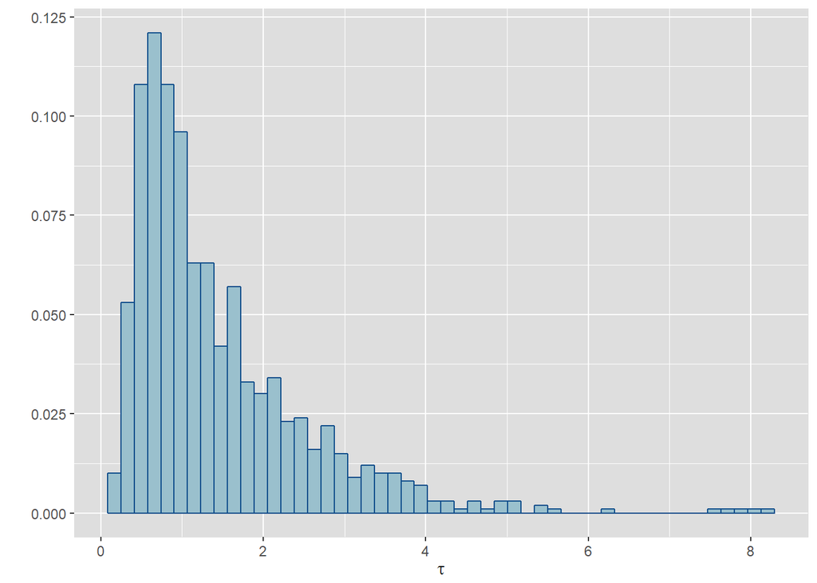

```r
histTau <- ggplot(densidadesTau, aes(x=tau))+
  geom_histogram(bins = 50, color="dodgerblue4", fill = "lightblue3", aes(y=..count../sum(..count..))) +   theme(panel.background = element_rect(fill = "gray87",
                                  colour = "gray87",
                                  size = 0.5, linetype = "solid"),
    panel.grid.major = element_line(size = 0.5, linetype = 'solid',
                                  colour = "white"),
    panel.grid.minor = element_line(size = 0.25, linetype = 'solid',
                                  colour = "white")
    ) +
  xlab(expression(tau)) +
  ylab("")

histTau
```

Adicionalmente, se puede marcar con una línea dónde se encuentra $\mathbb{E}_x(\tau)$:

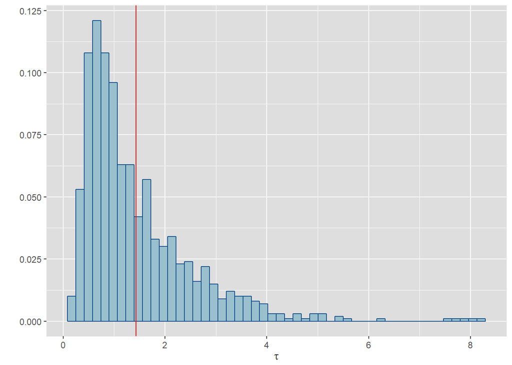

```r
histTau +
  geom_vline(xintercept=mean(densidadesTau$tau), color="red")
```